# complexSCsimulation: Simulation tool for single cell RNAseq data with complex differential expression and correlation structure

Qi Gao

2022-12-29

```r
library(complexSCsimulation)
library(Seurat)
```

```r
library(ggplot2)
set.seed(1)
```

## Introduction

**complexSCsimulation** is a single cell RNAseq data simulation method. Comparing to existing scRNAseq simulation methods, **complexSCsimulation** enable users to simulate datasets with complex and detailedly specified gene differential expression and correlation structure. Referring to **splat** method in **splatter** R package (Zappia, Phipson, and Oshlack (2017)), complexSCsimulation contains the following steps:

1. Simulate library sizes (log normal distribution)
2. Simulate gene means (gamma distribution) and differential expression fold changes (log normal distribution)
3. Add sub-cell-types
4. Add correlated genes (pathway gene and hub genes)
5. Simulate true counts
6. Simulate dropout

Using **complexSCsimulation**, we can simulate complex cell type structures, such as **senescent cells**. Senescent cells are very similar to their corresponding major cell types, sharing most of the feature genes, while having some additional senescent markers. Existing methods would be able to simulate cell types that are spatially close to each other in dimension reduction results. However, those adjacent cell types may not have underlying biological correlation with respect to differentially expressed feature genes. With our new method, we would be able to simulate sub-cell types and add some other correlation structures between genes. In this way, we can simulate a hierarchical structure of cells, making sub-cell types biologically similar to their major cell types.

## Quick start

```r
simdata <- complexSCsimulation(nCells = 6000, nGenes = 5000, nGroups = 5, drop = TRUE)
summary(simdata)
```

```
##               Length   Class  Mode
## counts        30000000 -none- numeric
## true.counts   30000000 -none- numeric
## groups            6000 -none- numeric
## library.size      6000 -none- numeric
## gene.mean.exp     5000 -none- numeric
## de.fc            25000 -none- numeric
## cor.list             0 -none- list
## hub.list             0 -none- list
```

In the output list, **counts** is the simulated data with dropout, while **true.counts** is the data matrix without dropout. In those data matrices, each row represents a gene, and each column represents a cell. Dropouts are simulated same as in the **splat** method, using a logistic function for calculation of probability.

```r
simdata$counts[1:5, 1:5]
```

```
##      [,1] [,2] [,3] [,4] [,5]
## [1,]    0    0    0    0    1
## [2,]    0    0    0    0    0
## [3,]    0    0    0    0    0
## [4,]    2    0    0    2    3
## [5,]    0    0    0    0    1
```

```r
simdata$true.counts[1:5, 1:5]
```

```
##      [,1] [,2] [,3] [,4] [,5]
## [1,]    0    0    0    0    1
## [2,]    0    0    0    0    0
## [3,]    0    0    0    0    0
## [4,]    2    0    0    2    3
## [5,]    0    0    0    0    1
```

**groups** shows the cell types of which the cells belong to. If sub-cell-types are included, those sub-cell-types would be numbered following the index of the base cell types.

```r
head(simdata$groups)
```

```
## [1] 1 2 3 4 5 1
```

The expected library size **library.size** is assumed to follow log normal distribution with **lib.size.loc** as location parameter and **lib.size.scale** as scale parameter.

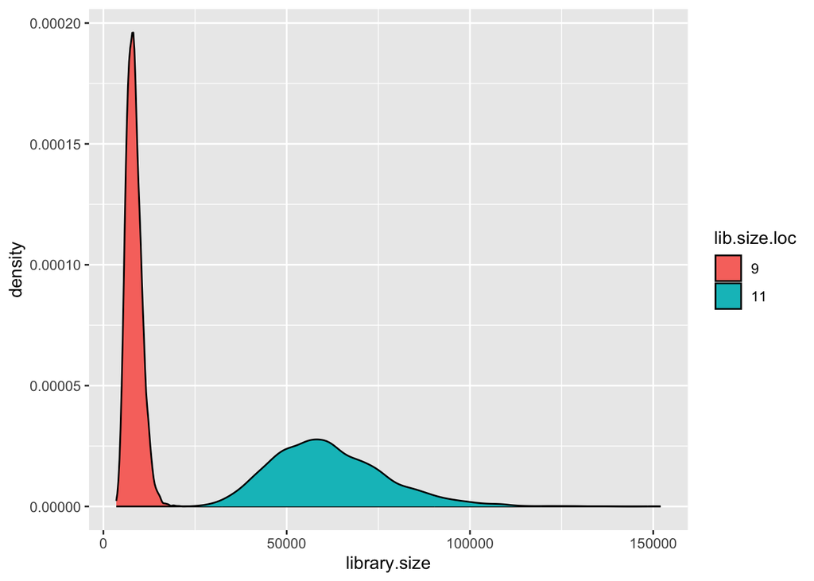

```r
simdata <- complexSCsimulation(nCells = 6000, nGenes = 5000, nGroups = 5, lib.size.loc = 9)
simdata1 <- complexSCsimulation(nCells = 6000, nGenes = 5000, nGroups = 5, lib.size.loc = 11)
plotdata <- data.frame(library.size = c(simdata$library.size, simdata1$library.size),
                       lib.size.loc = factor(c(rep(9, 6000), rep(11, 6000))))
g <- ggplot(plotdata, aes(x = library.size, fill = lib.size.loc)) + geom_density()
g
```

The unnormalized expected gene mean expression level **gene.mean.exp** is assumed to follow gamma distribution with **gene.mean.shape** as shape parameter and **gene.mean.rate** as rate parameter. The gene expression levels are then scaled by the library size.

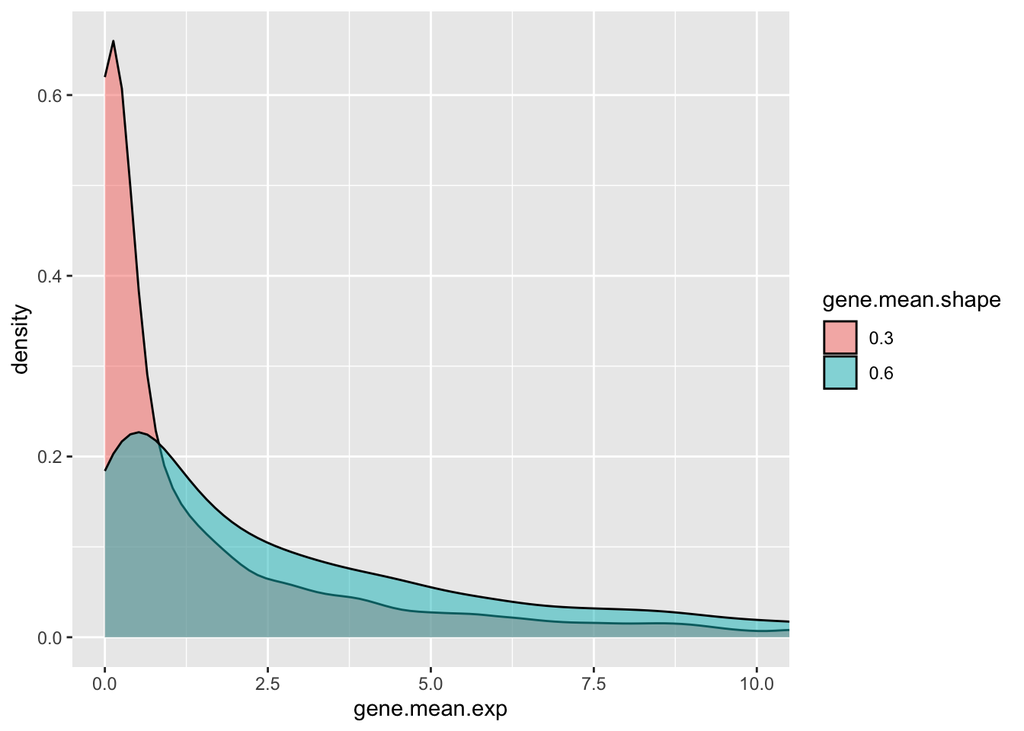

```r
simdata <- complexSCsimulation(nCells = 6000, nGenes = 5000, nGroups = 5, gene.mean.shape = 0.3)
simdata1 <- complexSCsimulation(nCells = 6000, nGenes = 5000, nGroups = 5, gene.mean.shape = 0.6)
plotdata <- data.frame(gene.mean.exp = c(simdata$gene.mean.exp, simdata1$gene.mean.exp),
                       gene.mean.shape = factor(c(rep(0.3, 5000), rep(0.6, 5000))))
g <- ggplot(plotdata, aes(x = gene.mean.exp, fill = gene.mean.shape)) + geom_density(alpha = 0.5) + coord_cartesian(xlim = c(0, 10))
g
```

**de.fc** contains information about differential expression fold change. Each row corresponds to a gene, and each column corresponds to a cell type (or sub-cell-type, corresponding to **groups**). The fold changes for differentially expressed genes are assumed to follow log normal distribution. Fold changes are applied to the mean (or expected) expression level of genes.

```r
simdata$de.fc[which(simdata$de.fc[,1] != 1), ]
```

```
##           [,1] [,2] [,3] [,4] [,5]
##  [1,] 3.685491    1    1    1    1
##  [2,] 1.589052    1    1    1    1
##  [3,] 1.793120    1    1    1    1
##  [4,] 2.409242    1    1    1    1
##  [5,] 2.696991    1    1    1    1
##  [6,] 2.365635    1    1    1    1
##  [7,] 1.483007    1    1    1    1
##  [8,] 1.730448    1    1    1    1
##  [9,] 1.788683    1    1    1    1
## [10,] 1.846381    1    1    1    1
## [11,] 1.462390    1    1    1    1
## [12,] 2.180395    1    1    1    1
## [13,] 2.020575    1    1    1    1
## [14,] 1.874526    1    1    1    1
```

[output cut: 36 more lines]

**cor.list** and **hub.list** would be introduced later.

## Differential expression structure

For all the following functions, we provide a default structure while allowing detailed assignments.

A simpler way is shown below. We use **de.n** to define the number of feature genes (differentially expressed genes across cell types), and **de.share** to define the number of shared feature genes between cell types.

```r
simdata <- complexSCsimulation(nCells = 6000, nGenes = 5000, nGroups = 5,
                      de.n = 10, de.share = rep(3, 4),
                      de.fc.loc = 0.7, de.fc.scale = 0.2)
apply(simdata$de.fc, 2, function(x){which(x != 1)})
```

```
##       [,1] [,2] [,3] [,4] [,5]
##  [1,] 1013    5 1690   64  440
##  [2,] 1134 1013 1774   78 1348
##  [3,] 1379 1134 1900 1584 1584
##  [4,] 1556 1600 1907 1774 2825
##  [5,] 2868 1690 2296 2825 3414
##  [6,] 3338 1900 3115 3115 3711
##  [7,] 3378 1964 3157 3157 3770
##  [8,] 3724 2296 3563 3316 4465
##  [9,] 4336 3704 4190 3770 4483
## [10,] 4882 3724 4518 4789 4774
```

As shown in the result above, the neighboring groups have 3 differentially expressed in common.

Another way of defining feature genes is to specify the detailed index with **de.id**. This type of definition would allows more complicated DE structure. The location parameter can also be defined correspondingly.

```r
simdata <- complexSCsimulation(nCells = 6000, nGenes = 5000, nGroups = 5,
                      de.fc.loc = list(rep(1, 5), rep(0.8, 5), rep(0.4, 5), rep(0.4, 5), rep(0.2, 5)),
                      de.fc.scale = rep(0.2, 5), de.id = list(1:5, 4:8, 7:11, 10:14, 13:17))
head(simdata$de.fc, 20)
```

```
##           [,1]     [,2]     [,3]     [,4]      [,5]
##  [1,] 4.190099 1.000000 1.000000 1.000000 1.0000000
##  [2,] 2.706893 1.000000 1.000000 1.000000 1.0000000
##  [3,] 2.375201 1.000000 1.000000 1.000000 1.0000000
##  [4,] 2.620960 3.128092 1.000000 1.000000 1.0000000
##  [5,] 3.024213 1.234656 1.000000 1.000000 1.0000000
##  [6,] 1.000000 2.952135 1.000000 1.000000 1.0000000
##  [7,] 1.000000 1.891785 1.455119 1.000000 1.0000000
##  [8,] 1.000000 1.522245 1.281917 1.000000 1.0000000
##  [9,] 1.000000 1.000000 1.923674 1.000000 1.0000000
## [10,] 1.000000 1.000000 1.201440 1.274111 1.0000000
## [11,] 1.000000 1.000000 1.310221 1.240297 1.0000000
## [12,] 1.000000 1.000000 1.000000 1.326944 1.0000000
## [13,] 1.000000 1.000000 1.000000 1.241601 1.2574442
## [14,] 1.000000 1.000000 1.000000 1.172272 1.3329244
## [15,] 1.000000 1.000000 1.000000 1.000000 1.2280601
## [16,] 1.000000 1.000000 1.000000 1.000000 0.8200719
## [17,] 1.000000 1.000000 1.000000 1.000000 1.5055577
## [18,] 1.000000 1.000000 1.000000 1.000000 1.0000000
## [19,] 1.000000 1.000000 1.000000 1.000000 1.0000000
## [20,] 1.000000 1.000000 1.000000 1.000000 1.0000000
```

## Add sub cell types

We define sub cell types as cells that share all the feature genes with the corresponding major cell type, but also have some additional feature genes.

**sub.major** defines the corresponding major cell type for each of the sub cell types. And similar as before, the differential expression structure can be defined in 2 different ways.

```r
simdata <- complexSCsimulation(nCells = 6000, nGenes = 5000, nGroups = 3,
                      de.fc.loc = list(rep(1, 3), rep(0.8, 3), rep(0.4, 3)),
                      de.id = list(1:3, 4:6, 7:9),
                      add.sub = TRUE, sub.major = 3:1, sub.prop = 0.1,
                      sub.de.n = 2, sub.de.common = TRUE)
apply(simdata$de.fc, 2, function(x){which(x != 1)})
```

```
## [[1]]
## [1] 1 2 3
##
## [[2]]
## [1] 4 5 6
##
## [[3]]
## [1] 7 8 9
##
## [[4]]
## [1]    7    8    9 1190 2673
##
## [[5]]
## [1]    4    5    6 1190 2673
##
## [[6]]
## [1]    1    2    3 1190 2673
```

```r
simdata <- complexSCsimulation(nCells = 6000, nGenes = 5000, nGroups = 3,
                      de.fc.loc = list(rep(1, 3), rep(0.8, 3), rep(0.4, 3)),
                      de.id = list(1:3, 4:6, 7:9),
                      add.sub = TRUE, sub.major = 3:1,
                      sub.de.id = list(10:11, 10:11, 10:11), sub.de.common = FALSE)
head(simdata$de.fc, 11)
```

```
##           [,1]     [,2]     [,3]     [,4]     [,5]     [,6]
##  [1,] 3.745901 1.000000 1.000000 1.000000 1.000000 3.745901
##  [2,] 3.638451 1.000000 1.000000 1.000000 1.000000 3.638451
##  [3,] 4.737330 1.000000 1.000000 1.000000 1.000000 4.737330
##  [4,] 1.000000 2.506653 1.000000 1.000000 2.506653 1.000000
##  [5,] 1.000000 1.874425 1.000000 1.000000 1.874425 1.000000
##  [6,] 1.000000 2.806015 1.000000 1.000000 2.806015 1.000000
##  [7,] 1.000000 1.000000 1.755052 1.755052 1.000000 1.000000
##  [8,] 1.000000 1.000000 1.379056 1.379056 1.000000 1.000000
##  [9,] 1.000000 1.000000 1.259789 1.259789 1.000000 1.000000
## [10,] 1.000000 1.000000 1.000000 1.899558 1.752314 2.077738
## [11,] 1.000000 1.000000 1.000000 1.808339 2.230849 2.288043
```

#### Simulate senescent cells

The following chunk shows an example of the simulation of senescent cells. When **sub.de.common** is set to be TRUE, the additional differentially expressed genes for all sub-cell-types are forced to be the same. This simulates the case where the senescent gene markers are the same for all the cell types.

```r
sendata <- complexSCsimulation(nCells = 10000, nGenes = 5000, nGroups = 4, groups = rep(1:4, c(1000, 2000, 3000, 4000)),
                      de.id = list(1:50, 51:100, 101:150, 151:200),
                      add.sub = TRUE, sub.major = 1:4, sub.group = list(1:50, 1001:1100, 3001:3150, 6001:6200),
                      sub.de.id = list(201:220, 201:220, 201:220, 201:220), sub.de.common = TRUE)
```

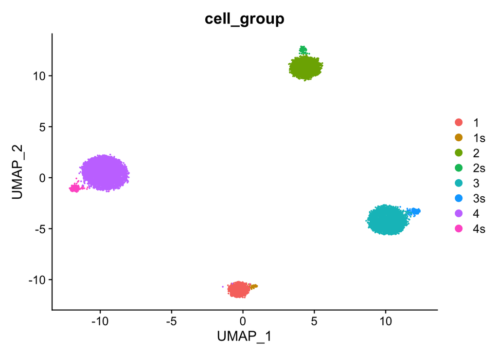

## Add correlated genes (pathway)

We assume genes in a pathway would be correlated with each other with AR(1) correlation structure and some fixed band width. The correlation between two pathway genes would be ignored if the distance between them in the pathway exceed the band width.

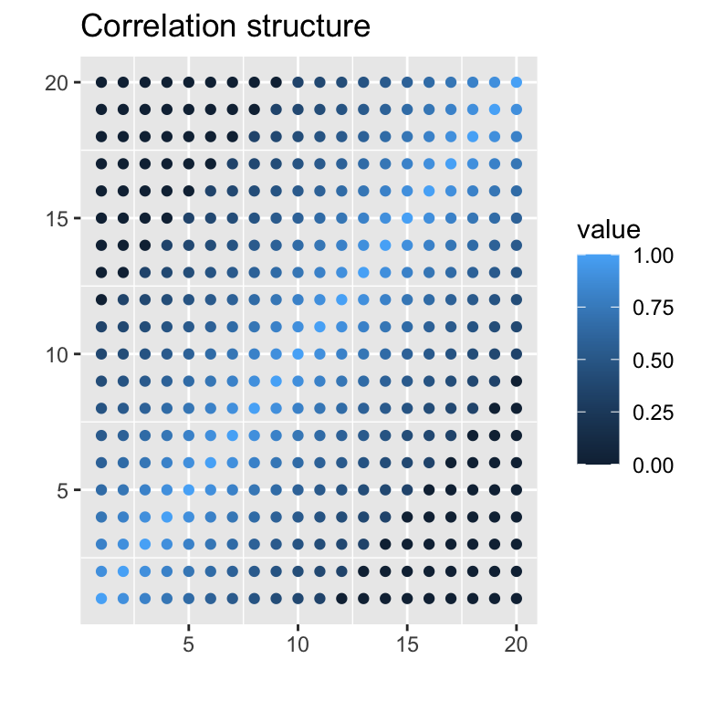

```r
simdata <- complexSCsimulation(nCells = 6000, nGenes = 5000, nGroups = 5,
                      add.cor = TRUE, cor.n = 4, cor.size = 10, cor.cor = 0.7, band.width = 5)
simdata$cor.list
```

```
## [[1]]
##  [1] 2225 2100  831 1044 2496 2022 3410 3170 2631 1018
##
## [[2]]
##  [1] 1455  510  181 4417 2736 3391 2025  725 1035 1511
##
## [[3]]
##  [1] 1787 3963  417 4407 2925 3308 1804 2122 3228 1579
##
## [[4]]
##  [1]  768 3682 1067 4507 1807  828 4832 2659 2827 4328
```

```r
simdata <- complexSCsimulation(nCells = 6000, nGenes = 5000, nGroups = 5,
                      add.cor = TRUE, cor.id = list(101:110, 111:120, 121:130, 131:140),
                      cor.size = 10, cor.cor = 0.7, band.width = 5)
simdata$cor.list
```

```
## [[1]]
##  [1] 101 102 103 104 105 106 107 108 109 110
##
## [[2]]
##  [1] 111 112 113 114 115 116 117 118 119 120
##
## [[3]]
##  [1] 121 122 123 124 125 126 127 128 129 130
##
## [[4]]
##  [1] 131 132 133 134 135 136 137 138 139 140
```

**cor.list** in the output shows the gene index in each of the pathways.

## Add hub genes

We assume hub genes to be genes correlated a lot of other genes while those genes may not have direct correlations with each others.

```r
simdata <- complexSCsimulation(nCells = 6000, nGenes = 5000, nGroups = 5,
                      add.hub = TRUE, hub.n = 3, hub.size = 10, hub.cor = 0.7)
simdata$hub.list
```

```
## [[1]]
##  [1] 3774  911 3776 1803 1383  410  696 2448 3216 2456 4119
##
## [[2]]
##  [1] 3475 3483 3577 4899 4399 2462 2818  659 2323 1055 2382
##
## [[3]]
##  [1] 4262 3826 2820 4222 4757 1182 1548 2869  768 2932 1295
```

First item in **hub.list** is the hub gene, while the other items are the genes correlated with the hub gene.

```r
simdata <- complexSCsimulation(nCells = 6000, nGenes = 5000, nGroups = 5,
                      add.hub = TRUE, hub.id = 1:3, hub.size = 10,
                      hub.cor = 0.7, hub.fix = list(11:13, 14:16, 17:20))
simdata$hub.list
```

```
## [[1]]
##  [1]    1   11   12   13  934 3242  806 3355 2165 3463  838
##
## [[2]]
##  [1]    2   14   15   16  642 1578 3986  344 4461 1571 3776
##
## [[3]]
##  [1]    3   17   18   19   20 4677 4136 1544 3343   65 4600
```

## Use self-defined DE structure

```r
simdata <- complexSCsimulation(nCells = 6000, nGenes = 5000, nGroups = 5, add.sub = T, sub.major = 1:5)
simdata1 <- complexSCsimulation(nCells = 6000, nGenes = 5000, nGroups = 5, sub.major = 1:5,
                       groups = simdata$groups, de.fc.mat = simdata$de.fc)
```

If the DE structures created by the simulation function is still not satisfactory, users can creat their own **de.fc** matrix and input it as **de.fc.mat**. The **nGroups**, **group** and **sub.major** arguments are also required.

## Reference

Zappia, Luke, Belinda Phipson, and Alicia Oshlack. 2017. “Splatter: Simulation of Single-Cell RNA Sequencing Data.” *Genome Biology*. https://doi.org/10.1186/s13059-017-1305-0.